# Predicting the Electoral College

Josh Clinton

8/16/2021

The trend in the popular vote is interesting, but not particularly relevant. Given the system of elections in the United States, what matters is the vote in the Electoral College. Thankfully we can apply many of the skills we just learned to study the pattern in each of the states.

```r
load(file = "data/StatePresidentalVote2020.Rdata")
glimpse(dat)
```

```
## Rows: 1,545
## Columns: 19
## $ poll.id        <dbl> 1, 13, 40, 41, 30, 24, 28, 29, 49, 26, 11, 12, 14, 48, …
## $ Geography      <chr> "UT", "CT", "WI", "CA", "MI", "FL", "GA", "MI", "WA", "…
## $ StartDate      <date> 2020-03-21, 2020-03-24, 2020-03-24, 2020-03-28, 2020-0…
## $ EndDate        <date> 2020-03-30, 2020-04-03, 2020-03-29, 2020-03-29, 2020-0…
## $ DaysinField    <dbl> 10, 11, 6, 2, 3, 5, 2, 2, 7, 3, 3, 3, 2, 2, 3, 4, 10, 1…
## $ MoE            <dbl> 2.8, 3.0, 4.2, NA, 4.0, 1.7, 3.0, 3.1, 4.1, 4.4, NA, NA…
## $ Mode           <chr> "Phone/Online", "Phone/Online", "Live phone - RDD", "Li…
## $ SampleSize     <dbl> 1331, 1000, 813, 962, 602, 3244, 1035, 1019, 583, 500, …
## $ Biden          <dbl> 41, 47, 48, 67, 46, 46, 46, 48, 52, 42, 48, 50, 52, 38,…
## $ Trump          <dbl> 46, 34, 45, 29, 46, 40, 48, 45, 39, 49, 47, 41, 43, 49,…
## $ DemCertVote    <dbl> 38, 59, 49, 64, 51, 48, 50, 51, 58, 49, 49, 51, 49, 41,…
## $ RepCertVote    <dbl> 58, 39, 49, 34, 48, 51, 49, 48, 39, 50, 49, 48, 49, 58,…
## $ Winner         <chr> "Rep", "Dem", "Dem", "Dem", "Dem", "Rep", "Dem", "Dem",…
## $ poll.predicted <dbl> 1, 1, 1, 1, 0, 0, 0, 1, 1, 1, 1, 1, 1, 1, 1, 1, 1, 1, 1…
## $ Funded         <chr> "UtahPolicy.com & KUTV 2News", "Sacred Heart University…
## $ Conducted      <chr> "Y2 Analytics", "GreatBlue Research", "LHK Partners Inc…
## $ region         <fct> utah, connecticut, wisconsin, california, michigan, flo…
## $ margin         <dbl> -5, 13, 3, 38, 0, 6, -2, 3, 13, -7, 1, 9, 9, -11, 6, -1…
## $ DaysToED       <drtn> 218 days, 214 days, 219 days, 219 days, 216 days, 213 …
```

The first step is to always get a snese of the data we have available to us. Critical for our purposes is just how many polls we have in each state.

As a reminder, there are two ways to get this data. First we can use the `count()` function from tidyverse to count the number of polls by region.

```r
dat %>%
  count(region)
```

```
## # A tibble: 50 × 2
##    region          n
##    <fct>       <int>
##  1 alabama        14
##  2 alaska         13
##  3 arizona       106
##  4 arkansas        8
##  5 california     20
##  6 colorado       28
##  7 connecticut     9
##  8 delaware        7
##  9 florida       129
## 10 georgia        73
## # … with 40 more rows
```

Alternative, using base R we can examine a table of the number of polls in each state by referencing the variable in the dat dataframe.

```r
table(dat$region)
```

```
##
##              alabama               alaska              arizona
##                   14                   13                  106
##             arkansas           california             colorado
##                    8                   20                   28
##          connecticut             delaware district of columbia
##                    9                    7                    0
##              florida              georgia               hawaii
##                  129                   73                    7
##                idaho             illinois              indiana
##                    6                   10                   14
##                 iowa               kansas             kentucky
##                   42                   16                   18
##            louisiana                maine             maryland
##                   11                   24                   11
##        massachusetts             michigan            minnesota
##                   13                  130                   44
##          mississippi             missouri              montana
##                   11                   19                   25
##             nebraska               nevada        new hampshire
##                    5                   22                   22
##           new jersey           new mexico             new york
##                   19                   11                   13
##       north carolina         north dakota                 ohio
##                  134                    7                   52
##             oklahoma               oregon         pennsylvania
##                   10                    8                  143
##          puerto rico         rhode island       south carolina
##                    0                    5                   26
##         south dakota            tennessee                texas
##                    7                    8                   65
##                 utah              vermont             virginia
##                   14                    7                   20
##           washington        west virginia            wisconsin
##                   13                    8                  112
##              wyoming
##                    6
```

What you realize immediately is that there is a wide variety in the number of polls that were being done at the state level in 2020. States that were thought to be closely contested like Pennsylvania had 143 polls while uncompetitive states like Tennessee had only 8 polls done in total. This immediately suggests that the approach we took in analyzing the national popular vote by analyzing the trend over time may not be as interesting or as viable given the limited data.

Even so, let us see what analyzing the trend in the state with the most polls – Pennsylvania – might reveal.

Defining all_dates to span the state presidential polls and using the poll_ma function we defined earlier applied to our state presidential polling data filtered to the state of Pennsylvania reveals a time series of not much interest. Early on there is not much data and there are weeks of time in which not a single poll is done. By September, however, there exist enough polls to be able to calculate a 7-day smoothed average but the trend is relatively stable. You can identify a few extreme poll results, but the overall trend is relatively stable.

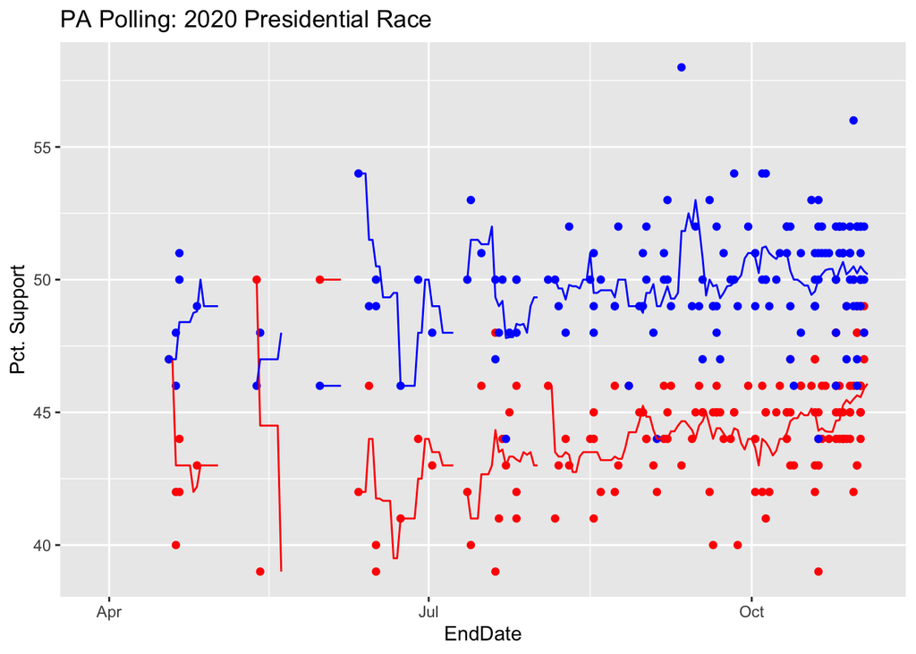

```r
all_dates <- seq(min(dat$EndDate), election.day, by = "days")

pa.ma <- map_df(all_dates, poll_ma, filter(dat,Geography=="PA"))
ggplot(filter(dat,Geography=="PA")) +
  geom_point(aes(x = EndDate, y = Trump), color = "red") +
  geom_point(aes(x = EndDate, y = Biden), color = "blue") +
  labs(title="PA Polling: 2020 Presidential Race") +
  labs(y = "Pct. Support") +
  geom_line(data=pa.ma, aes(x = date, y = Trump), color = "red") +
  geom_line(data=pa.ma, aes(x = date, y = Biden), color = "blue")
```

Inspecting the results of Pennsylvania suggests that following the approach we took in analyzing the national popular vote is unlikely to be of much use. There is not enough polling being done in enough states over time to make an overtime comparison of presidential support in the states particularly compelling. Instead of trying to estimate support over time across states, let us instead focus on estimating the support in each state at the end of the campaign. This will allow us to use the poll results to compute our best estimate based on the polling data as to what should have happened so that we can compare it to what actually did.

To begin, let’s analyze every poll that was done in a state regardless of when it occurred. Based on our analysis of both the national popular vote and also the most heavilty polled state of Pennsylvania, there is very little evidence of movement over time. As a result, it may be sensible to use every poll in every state rather that limiting the polls to a certain time period.

To do so we are going to create an object whereby we are going to compute the average support for Biden and Trump by state thru the use of both `group_by()` and `summarize()`. We will remove missing data when taking the means to protect us from missing data, but there should not be any given the nature of the data.

```r
State.mean <- dat %>%
  group_by(region) %>%
      summarize(BidenPct = mean(Biden, na.rm = TRUE),
                TrumpPct = mean(Trump, na.rm = TRUE),
                NumPolls = n())
```

Now we have an object called State.mean that contains the average support for Biden and Trump in each state using every public poll conducted during the 2020 presidential election. What should we do with this object. Many people immediately reach for a map of the country to plot the results so let’s discuss how to do this before taking a step back to consider whether it is a good representation of the information and variation of interest.

We are going to use the maps package so we will install it and then, once installed, read it into memory so we can use the functions defined in the package. As with all graphing in R we begin by creating the canvass on which we will plot our data. When doing a map this requires creating the map that we will then augment with the data of interest. The maps library has many such canvasses – both international and within the United States (e.g., counties) – but we want to work with states as the unit of analysis given that our polling data varies by states.

```r
#install.packages("maps")
library(maps)
```

To create our map we want to extract the data needed to create a “blank” map of the lower 48 states. To do so we create an object that we will call states48 from the `map_data()` contained in the maps library. Then we will create a ggplot object and add to the object the polygon defined by the state boundaries. In calling the geom_polygon, our data is the states48 object we just extracted and the variables we are plotting to define the states include the longitude (`long`) for the x-axis and the latitde (`lat`) for the y axis. To prevent the uninformative axes titles of “long” and “lat” we define the x and y axes to be blank. We color the states “lightblue” for no particular reason.

```r
states48 <- map_data("state")
dim(states48)
```

```
## [1] 15537     6
```

```r
states48[1,]
```

```
##        long      lat group order  region subregion
## 1 -87.46201 30.38968     1     1 alabama      <NA>
```

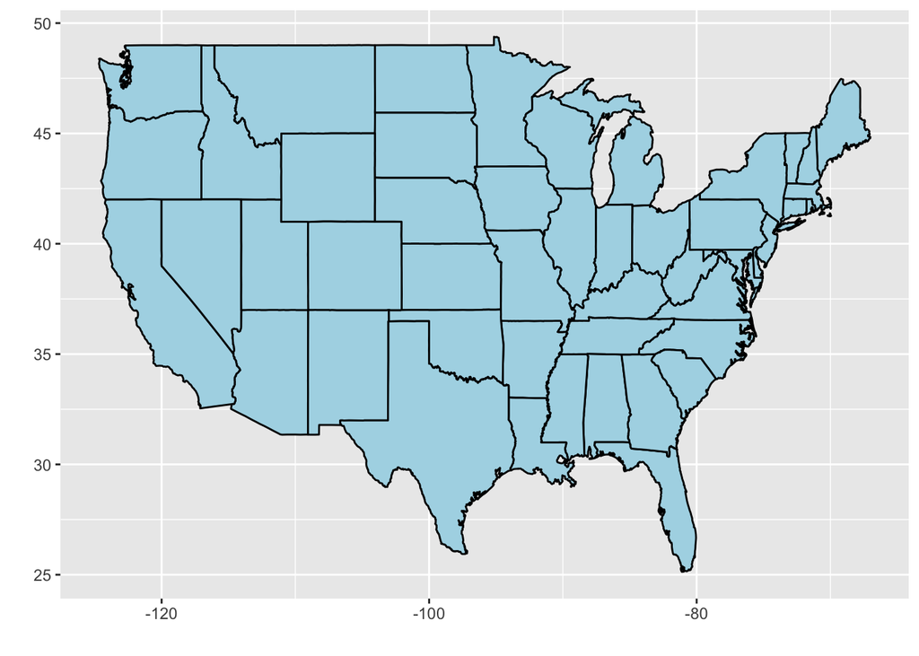

```r
ggplot() +
  geom_polygon( data=states48, aes(x=long, y=lat, group=group),
                color="black", fill="lightblue" ) + labs(y = "") + labs(x = "")
```

So we have produced a plot, but it conveys absolutely no information about the 2020 election. To do so we need to combine the polling data we created above with the plotting data we juse used. To do so we use the inner_join command that will compare two dataframes – here `states48` and `State.mean` – for a commonly defined variable (here `region`) and then join the dataframes together into a new dataframe we have called `states48.join`. The inner join refers to the fact that the new dataframe will consist only of the observations that are present in *both* dataframes. If data is present in one and missing in the other the observation will be dropped. The outer_join command combines dataframes using all observations that appear in either of the dataframes (and creates missing values for the observations missing in the other dataframe).

```r
states48.join <- inner_join(states48,State.mean)
states48.join[1,]
```

```
##        long      lat group order  region subregion BidenPct TrumpPct NumPolls
## 1 -87.46201 30.38968     1     1 alabama      <NA> 38.92857 56.78571       14
```

With this joined data we now have a data frame that has both the latitude and longitude needed to plot on the ggplot map we created, but also the polling averages that we can use to convey information. Now things get a bit tricky. What information do we want to try to convey about the polling averages do we want to try to convey using the map. One possibility is to use the map to indicate which states are competitive or not for each candidate.

To do so we want to create several `geom_polygon()` objects where we are going to apply some filters to the joined data that identify political interesting situations and then fill in the states satisfying those conditions using different colors. So if we want to indicate which states Biden was predicted to beat Trump based on the polling average we can create a geom_polygon that filters the `states48` object to select states where `BidenPct > TrumpPct`. To plot this to the ggplot object we need to use the aesthetics associated with the map – so `x=long`, `y=lat` and `group = group` – and indicate that `fill="Blue"`. Indicating the states that were predicted to be won by Trump can be done similarly.

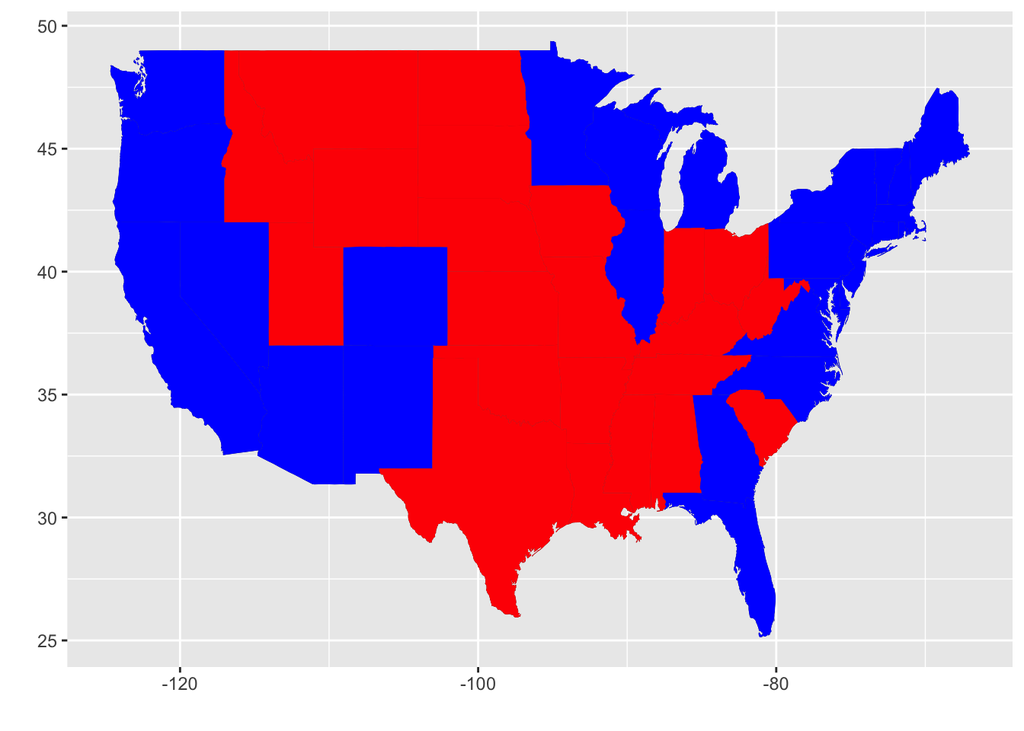

```r
statewinner <- ggplot() +
  geom_polygon(data=states48.join, aes(x=long, y=lat, group=group)) +
  geom_polygon(data=filter(states48.join,BidenPct > TrumpPct), aes(x=long, y=lat, group=group),fill="Blue") +
  geom_polygon(data=filter(states48.join,BidenPct < TrumpPct), aes(x=long, y=lat, group=group),fill="Red") + labs(y = "") + labs(x = "")
statewinner
```

Another way to accomplish the same task is to use the fill command to define different colors based on different values or conditions. Unlike the above code that used filters to define separate `geom_polygon`, we can also define the color of the fill to vary depending on if the logical (i.e., true/false) condition `BidenPct > TrumpPct` is met.

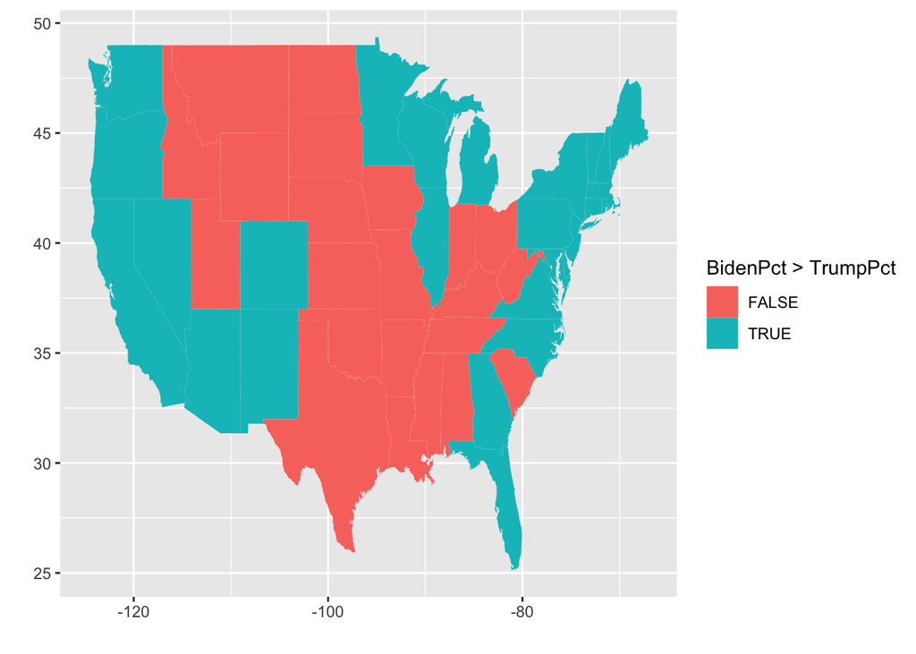

```r
g <- ggplot() +
  geom_polygon(data=states48.join, aes(x=long, y=lat, group=group,fill=BidenPct > TrumpPct),
               color="white", size = .01) + labs(y = "") + labs(x = "")
g
```

While there are several aspects of the resulting map that we may worry about, one concern is that it does not distinguish between states that are predicted to be lopsided versus states that are expected to be extremely close. We can add this information to the plot by using more geom_polygon() and some additional filters to identify states where a candidate is predicted to win, but where the average difference in the polls is less than 2 points. To distinguish this from the other states we will fill them using light blue for Biden and light red for Trump. Note that the states being selected in this filter have already been selected and filled based on the code we just ran. The order of operations matters here because whatever is done last will remain. In the case of close states, they will first be colored Red or Blue and then their color will be replaced with either light blue or light red. Let’s make it happen.

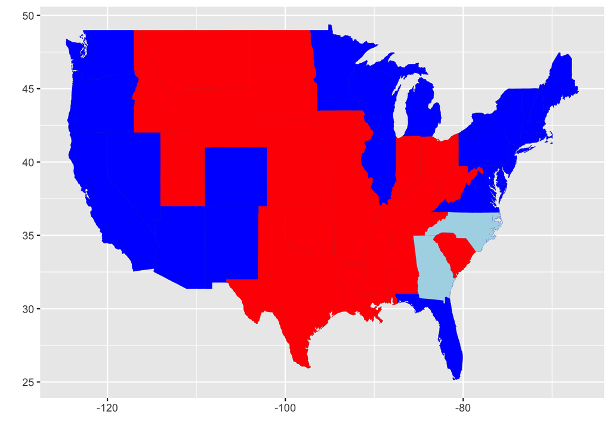

```r
  statewinner +
  geom_polygon(data=filter(states48.join,BidenPct > TrumpPct & BidenPct - TrumpPct < 2), aes(x=long, y=lat, group=group),fill="light blue")
```

```r
  geom_polygon(data=filter(states48.join,BidenPct < TrumpPct & BidenPct - TrumpPct > 2), aes(x=long, y=lat, group=group),fill="light red")
```

```
## mapping: x = ~long, y = ~lat, group = ~group
## geom_polygon: na.rm = FALSE, rule = evenodd
## stat_identity: na.rm = FALSE
## position_identity
```

Hmm. We picked up two states that Biden was predicted to win by a narrow margin: Georgia and North Carolina. While alarm bells should be going off in your head if you know about the outcome of the 2020 election, let’s put that issue aside for now and push onwards in our attempt to convey information using a geographic representation of polling data. The categorical outcomes that we have defined based on our polling averages are coarse and not very informative. We have basically converted a continuous measure of average polling support for each candidate to a categorical variable that indicates whether the state was: won by more than 2 points by Biden, won by less than 2 points by Biden, won by less than 2 points by Trump, and won by more than 2 points by Trump.

Can we do better? Can we use the map – and the fill command in particular – to try to convey information about a continuous variable? It turns out that we can in theory, but whether we ought to do so is another question entirely. But let’s get the techncial skills covered first. The basic idea is to use the fill command in geom_polygon to reflect the continuous variation we wish to depict.

There a couple of ways we can try to do this. First we can use the fill command to define a color based on the average support that Biden (or Trump) is predicted to receive. To help denote the location of states we have used `color="white"` to label state boundaries and set the size of the state borders to be .01.

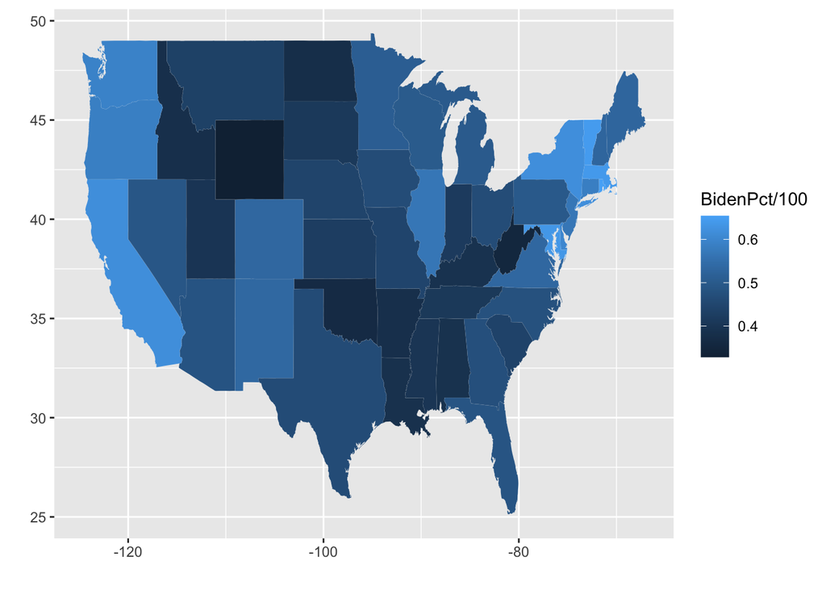

```r
g <- ggplot() +
  geom_polygon(data=states48.join, aes(x=long, y=lat, group=group,fill=BidenPct/100),
                color="white", size = .01) + labs(y = "") + labs(x = "")
g
```

While this depicts that the polls predicting varying levels of support for Biden, the color scheme is unintuitive and, because of that, distracting. If a graph is distracting to the reader, it fails in its fundamental job of conveying information. Note also that the legend is named the rather in terms of R variables rather than understandable concepts. Legends and labels should always be readily interpretable and understandable by readers. This fails that basic test.

We can indicate variation another way by having R automatically use the variation in the varable of interest to define the changes in color. Instead of defining the fill color using the continuous variable, we are now going to use the scale_fill_continuous() function to use the variable being filled (still `BidenPct/100`) to vary from the minimum value (which will be filled using the color given by low (here Red) to the highest value (here Blue)). Note that we are specifying the name to be “Biden Pct” so that the resulting legend is more informative than it was.

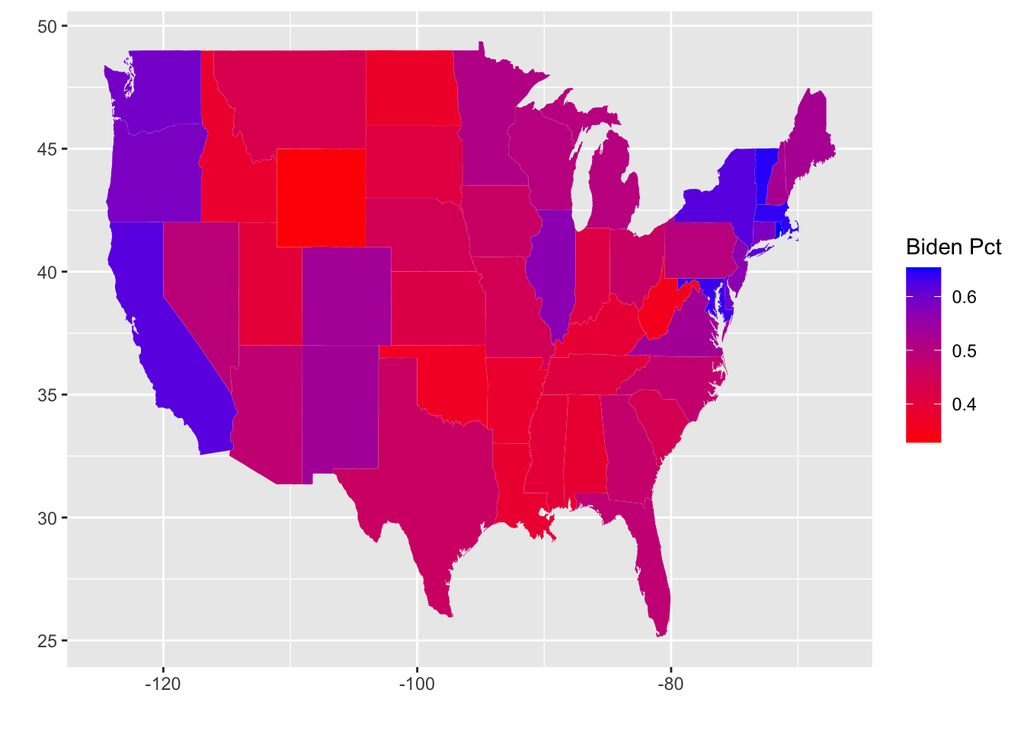

```r
g + scale_fill_continuous(name="Biden Pct",
                      low = "Red", high = "Blue")
```

So now we can tell which states favored Trump and which states favored Biden based on the polling averages and whether the states are colored REd or Blue, but how informative do you really find this presentation of data? For states that are closely contested – i.e., the purplish states – can you tell how many favor Biden and how many favor Trump? And if you suffer from color-blindness such as I do, good luck interpreting what you see.

Despite the frequent use of maps to analyze political data, a persuasive argument can be made that they are uninformative and perhaps even misleading. Recall that we want to characterize data and that data is always being intepreted and understood as being in relation to something else. When you present the data in a map you are emphasizing the geographic aspect of the data. But why is that the relevant context? If you are making an argument related to regionalism – e.g., how the south is different politically from the northeast or the west because of reasons related to american political development – then perhaps the geographic arrangement of the data is informative, but in many cases this seems irrelevant. If I want to understand the level of support for Biden does a map convey more information than a histogram? The map makes it very hard to determine basic summary feature such as how concentrated the support for Biden is across states and how much it varies. The visualization of the map leads your mind to think in terms of the graphical representation of the states – and consequently how large the land area of each is – rather than the the distribution of support for Biden.

Consider in contrast, a histogram that plots the distribution of the Biden polling averages in the state polls. The histogram reveals that there are a handful of states where Biden won handily, a bunch of closely contested states, and some states that he lost by a great deal. Moreover, the most frequent range was a state slightly under 50% – suggesting that there are a large number of states that Biden was close to winning but where he closely lost.

To create the histogram we are going to plot the distribution of Biden polling averages across states. To focus attention, we are goign to define the x-axis to vary from 30 percent to 70 percent using the `xlim` command and we are going to create the histogram bars that indicate how many states have polling averages in each interval that are filled to be blue. Note that ggplot defaults to have 30 “bins” (i.e., bars), which the tidyverse description curiously notes is inadequate and a bad default: “By default, the underlying computation (stat_bin()) uses 30 bins; this is not a good default, but the idea is to get you experimenting with different number of bins.” As a result, we define each bar to be 2.5 percentage points wide. Given the xlim we have chosen, the bars will indicate the number of states with a Biden polling average between: (30,32.55),[32.5,35),[35,37.5), and so on.

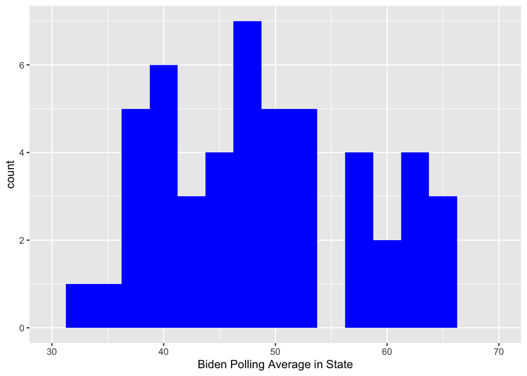

```r
ggplot(data=State.mean) +
  xlim(30,70) +
  labs(x="Biden Polling Average in State") +
  geom_histogram(mapping = aes(BidenPct), fill = "blue", binwidth=2.5)
```

So which representation of the data is better? As with most questions in data science the answer depends critically on the question you want to answer and the aspects that you wish to emphasize to your audience. Do you care about the geographic location of Biden support? Then perhaps a map makes sense, but realize that the map is still possibly misleading because the geographic area of a state is uncorrelated with political power so a map that contains a lot of “red” may provide a misleading indication of support and political power.

A histogram removes the distraction created by the geographic representation to focus more specifically on the data being analyzed, but imperfections remain. ALthough the data is now divided into bins that can be defined by the data scientist, it is still plotting observations (i.e., states). But not every state possesses equal political power and it can be possible to be mistake frequency of state support with political power. There are clearly more states where Biden received less than 50 percent than more, but Biden won the presidency. The discrepancy is not because of polling errors – which actually overstated Biden’s support in 2020 – but it is because what matters is not the number of states that are won but the population of those states.

# Did We analyze the right data? What if we only look at the Last 14 days?

Do we get a different answer if we focus on the polls conducted in the last two weeks? To determine this we need to know how the percentages compare. While we could attempt to eyeball two maps to see if they look different, this is what scatterplots are meant for – we can compare the BidenPct and TrumpPct computed using all polls and just those done in the final 14 days to see how similar they are.

```r
State.mean.Last14 <- filter(dat,DaysToED <=14) %>%
  group_by(region) %>%
  summarize(BidenPct14 = mean(Biden),
            TrumpPct14 = mean(Trump),
            NumPolls14 = n())
```

```r
State.Mean <- inner_join(State.mean, State.mean.Last14)
```

What percentage of the polls were done in the last 14 days? If a most states had most of their polls done at the end then the decision to use all polls or just the last 14 days may not matter. To do this we can simply calculate the fraction of polls in each state done within the last 14 days by taking the ratio of the number of state polls done in the last 14 days divided by the total number of state polls.

```r
State.Mean$NumPolls14/State.mean$NumPolls
```

```
##  [1] 0.4285714 0.3076923 0.2641509 0.3750000 0.2000000 0.2500000 0.4444444
##  [8] 0.2857143 0.3488372 0.3013699 0.2857143 0.3333333 0.6000000 0.4285714
## [15] 0.3333333 0.3750000 0.2222222 0.3636364 0.2500000 0.3636364 0.3076923
## [22] 0.2692308 0.3409091 0.3636364 0.2631579 0.2800000 0.4000000 0.4090909
## [29] 0.2727273 0.3157895 0.2727273 0.3076923 0.2761194 0.2857143 0.3461538
## [36] 0.3000000 0.3750000 0.3146853 0.4000000 0.3461538 0.5714286 0.3750000
## [43] 0.3076923 0.2142857 0.4285714 0.4000000 0.2307692 0.3750000 0.2142857
## [50] 0.5000000
```

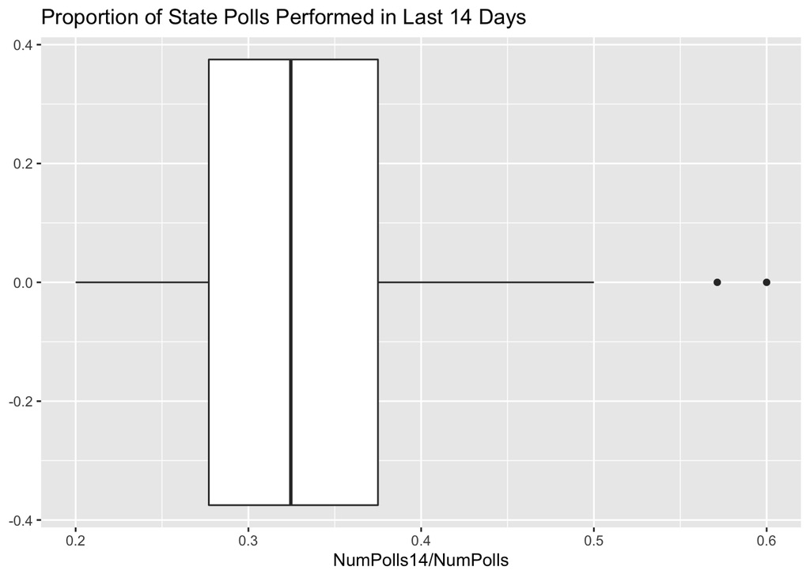

```r
ggplot(data = State.Mean)  +
  labs(title="Proportion of State Polls Performed in Last 14 Days") +
  geom_boxplot(aes(x = NumPolls14/NumPolls))
```

The results of the boxplot reveal that most of the state level polls in most states were conducted prior to the last 14 days. This should make us concerned about the possibility that our data is misleading because it fails to reflect changes in the race happening closer to Election Day. After all, the only opinions that matter are the opinions that the voters have when they go to cast their vote – what voters thought in April are irrelevant for how they will vote in November if they have changed their mind.

So is there evidence they changed their mind? Or, more precisely, that the support for Biden and Trump changed over time in ways that would make it misleading to use all of the polls to predict the outcome? To do so we can compare how the average support for Biden computed using all polls compares to the average support for Biden using only those polls that were conducted in the last 14 days. The graphical tool we want to use to do this comparison is the scatterplot. The question we want to ask is how closely related is `BidenPct` to `BidenPct14` – if the percentages are similar, then the differences in our predictions will likely be slight. So let’s see by graphing the two polling averages against one another.

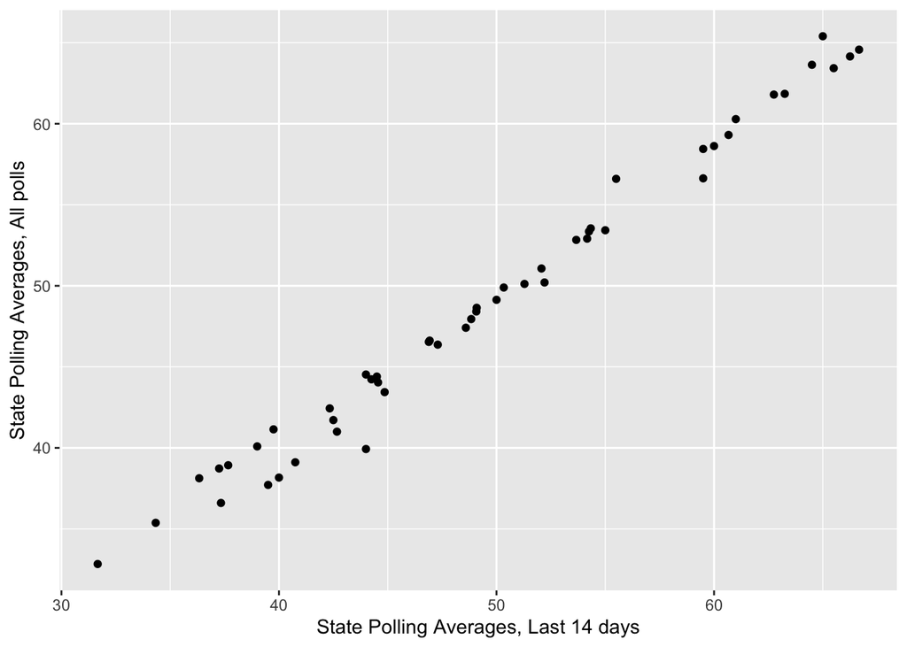

```r
ScatterMeans <- ggplot(data = State.Mean, aes(x = BidenPct14, y = BidenPct)) +
  geom_point() +
  labs(x = "State Polling Averages, Last 14 days") +
  labs(y = "State Polling Averages, All polls")
ScatterMeans
```

The relationship looks very similar - suggesting that it does not matter much whether we filter the data to focus on the polls conducted in the last 14 days. There are a few differences – but the differences appear more common in states where the support is higher or lower than average. Most critically for our purposes, the biggest of the small differences seem to occur in states where Biden is losing badly and where the differences are therefore inconsequential for predicting who should win the state.

But the scatterplot may be unsatisfying as we may be curious as to where the differences are occurring. Which states are most affected by the decision of which polls to analyze? To answer this question we can use the geom_text command to label the points. Recall that the state names in our State.Mean dataframe are called region. So to add state names to the ggplot object `ScatterMeans` we just created we need to add this additional element to the plot.

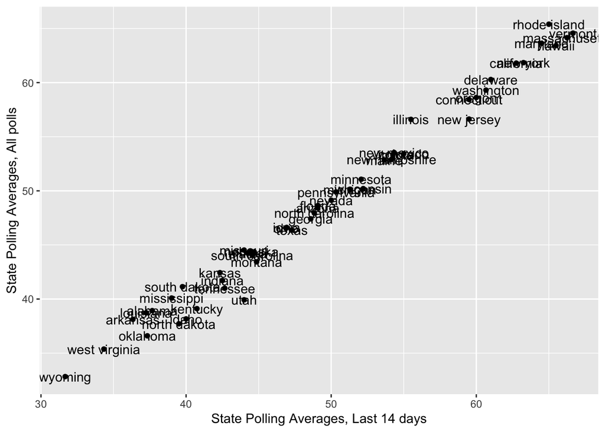

```r
ScatterMeans + geom_text(data = State.Mean, aes(label = region))
```

Hmm. Hard to read. If anything, we have made the plot worse as the labels are too large to distinguish and the points that we plotted make some of the letter illegible. So let’s try to correct this by redoing the plot.

This time we are going to add the `geom_text` *without* adding the points. This means that we will not have the points to obscure the text of the labels we are plotting. We are also going to adjust the size of the text by specifying `size=2`.

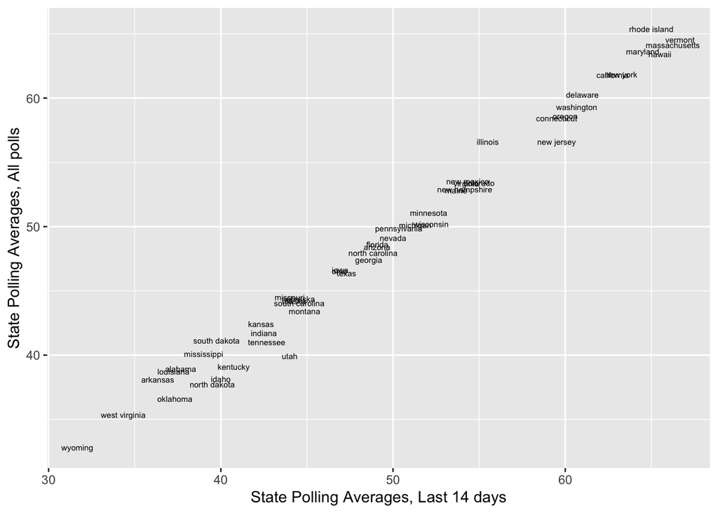

```r
ScatterMeans.new <- ggplot(data = State.Mean, aes(x = BidenPct14, y = BidenPct)) +
  labs(x = "State Polling Averages, Last 14 days") +
  labs(y = "State Polling Averages, All polls") +
  geom_text(data = State.Mean, aes(label = region), size = 2)
ScatterMeans.new
```

Better! Now we can identify which states seem to fluctuate based on the filter of polls being analyzed. But our ability to make this comparison is still hampered because it is hard to tell how far the polling averages in each state vary depending on the filter being used. What we really want to know is where the percentages are different from one another. To help convey this information we can use the fact that the 45-degree line – i.e., a line with a y-intercept of 0 and a slope of 1 indicates the points for which the x and y values are equal. In other words, points along the 45-degree line are states in which the polling averages are identical regardless of the filter being used! Points to the “right” of the line indicate states where Biden’s polling average increases if we use only the polls conducted in the last 14 days and points to the left indicate states where Biden’s polling average decreases.

So let’s add the 45-degree line. One thing we also want to do to help ease the interpretation is to make sure that the x-axis and the y-axis are on the same scale. This way the 45-degree line will go from the lower left to the upper right of the plot. To do so we define `xlim` and `ylim` to both range from 30 to 75. To add the 45-degree line we use `geom_abline` to specify the slope and y-intercept to be 1 and 0 respectively.[^1]

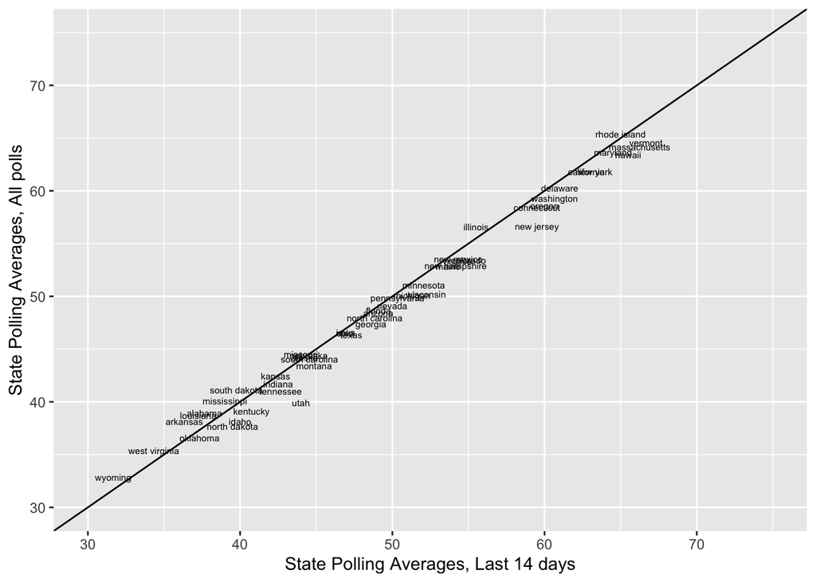

```r
ScatterMeans.new +
  geom_abline(intercept = 0, slope = 1) +
  xlim(30,75) +
  ylim(30,75)
```

Much better! Now we have a better benchmark and context – the 45-degree line – to determine whether the differences in samples being analyzed are likely to matter. Given the similarities, it seems that there is no real difference to our analysis whether we use all polls or just those done in the last 14 days because the differences are generally small. If anything, using the set of all polls may slightly underestimate the support for Biden as there are more states to the right of the 45-degree line than to the left of it.

# Resampling to Compute Probability of Winning

So this tells us the polling average for Biden and Trump in each state, but recall that we always want to try to quantify our uncertainty. So if Biden is predicted to get 47 percent and Trump is predicted to get 45 percent, how does that translate into the probability that Biden is going to win? Does the fact that Biden has a 2 percent lead in the average polls mean that he is going to win with certainty? Of course not becasue we know that there is sampling error in the polls *even if they are a random sample of the electorate’s voting intentions*. Even if we assume that the polls are correctly measuring the electorate (i.e, we can identify who is going to vote) and that they are all random samples from the electorate (i.e., we can randomly select those voters and the voters who respond to our polls are a random sample of the voters that are attempted to be interviewed), we know that the sample means may differ from the truth because of the random samples being drawn. We also know that the more polls we have, the closer the polling mean is likely to be to the true opinions of the electorate.

To illustrate what we can do using the resampling approach, let’s focus on the pivotal state of Pennsylvania. To determine how much the polling average varies we are going to repeatedly sample (with replacement) from the set of Pennsylvania polls we have collected, calculate the polling average for Biden and Trump each time, and then use the variation in the polling averages across these samples to quantify how much the polling averages may vary based on sampling alone. We are going to use the set of all polls, although we could easily replicate the results using only those conducted in the lat 14 days (which is something you should to to confirm that you understand what is being done).

We being by creating a dataframe of all public Pennsylvania state-level presidential polls using the filter command. Then we create our holding variable – prob.win – where we are going to collect the polling averages for each of the `NSamples` simulations we are going to conduct. For each iteration i we are going to use sample_n to draw a random sample of polls (with replacement of course) containing the same number of polls that were performed (i.e., `nrow(PA.dat)`). We are going to use the resulting sample `samp` to determine whether Biden is leading Trump in the polling average by having R evaluate the logical condition `samp$Biden > samp$Trump` – which returns a value of TRUE (1) or FALSE (0) – and take the mean of this logical condition to determine the proportion of polls for which Biden is leading Trump. We save the proportion associated with the ith sample in the ith element of `prob.win`. Note that we rewrite `samp` each iteration because there is no need to save the random samples.

```r
PA.dat <- filter(dat,Geography=="PA")

prob.win <- NULL
NSamples <- 100

for(i in seq_along(NSamples)){
  samp <- sample_n(PA.dat,nrow(PA.dat),replace = TRUE)
  prob.win[i] <- mean(samp$Biden > samp$Trump)
}
```

So the point of resampling is that we can now use prob.win to make inferences about the variation that we can expect to occur in prob.win due to random sampling in the polls being analyzed. Taking the mean gives our best estimate of the probability that Biden will win – assuming that leading in the polls is equivalent to winning in the election – and we can also see how much that probability varies across simulations that randomly vary the polls that are included in that calculation.

```r
mean(prob.win)
```

```
## [1] 0.951049
```

```r
summary(prob.win)
```

```
##    Min. 1st Qu.  Median    Mean 3rd Qu.    Max.
##   0.951   0.951   0.951   0.951   0.951   0.951
```

Since we are going to do this a bunch, let’s practice our function writing skills and write a function that will data a dataframe (.data) and a number indicating the number of samples that are desired (`NSamples`) to compute the probability of winning. The function `winprob` will return the probability of winning from 1000 samples (Of course, the Law of Large numbers says that this average will be the same as the average in the original sample we are resampling so this exercise is largely illustrative).

```r
winprob <- function(.data, NSamples){
    prob.win <- NULL

    for(i in 1:NSamples){
    npolls <- nrow(.data)
    samp <- sample_n(.data, npolls, replace = TRUE)
    prob.win[i] <- mean(samp$Biden > samp$Trump)
    }

    mean(prob.win)
}
```

With this function we can apply it to the Pennsylvania polls and 200 resamples to see that, as expected by the LLN, the average is nearly identical. This highlights the important point that the power of resampling is not in determining the central tendency (i.e., mean), but it is extremely useful for quantifying variation (due to random sampling). We will return to this point later, but for now let us push forward to illustrate what can be done to generate probabilities for every state.

```r
winprob(.data = PA.dat, NSamples = 200)
```

```
## [1] 0.9162587
```

Because we want to apply this function to every state we want to loop along the list of state names, apply winprob to the polls that were conducted in each state, and then extract the percentage of polls in which Biden was leading as our estimate of the probability of Biden winning and save the resulting estimate for the ith state into the object ProbBidenLead that we define prior to looping.

To identify the list of states that we are going to loop over we are going to use the unique command that returns a vector of unique values in an object.

```r
states <- unique(dat$Geography)
states
```

```
##  [1] "UT" "CT" "WI" "CA" "MI" "FL" "GA" "WA" "NC" "AZ" "MS" "IN" "TX" "MT" "CO"
## [16] "IA" "PA" "NJ" "NY" "NM" "OH" "TN" "NH" "NV" "MA" "VA" "KY" "MN" "MD" "SC"
## [31] "MO" "KS" "OK" "AR" "AL" "ME" "AK" "HI" "LA" "DE" "ID" "WY" "WV" "VT" "SD"
## [46] "RI" "OR" "NE" "ND" "IL"
```

We can then use this object to create our loop by telling R to loop along the list of states we have. In so doing we start at the first observation – `states[1]` and we end at `states[50]`.

```r
ProbBidenLead <- NULL
for(i in seq_along(states)){
  hold.dat <- filter(dat, Geography == states[i])
  ProbBidenLead [i] <- winprob(hold.dat,100)
}
```

The output is:

```r
ProbBidenLead
```

```
##  [1] 0.00000000 1.00000000 0.96526786 1.00000000 0.91246154 0.80031008
##  [7] 0.55452055 1.00000000 0.71350746 0.84301887 0.00000000 0.00000000
## [13] 0.31046154 0.00000000 1.00000000 0.27785714 0.91867133 1.00000000
## [19] 1.00000000 1.00000000 0.39500000 0.00000000 1.00000000 0.95181818
## [25] 1.00000000 1.00000000 0.00000000 0.97522727 1.00000000 0.00000000
## [31] 0.05263158 0.00000000 0.00000000 0.00000000 0.00000000 1.00000000
## [37] 0.00000000 1.00000000 0.00000000 1.00000000 0.00000000 0.00000000
## [43] 0.00000000 1.00000000 0.00000000 1.00000000 1.00000000 0.00000000
## [49] 0.00000000 1.00000000
```

To help us work with this later, we want to associate the probabilities with states and produce a tibble that we could use for future analysis and merging. Having objects floating in the Environment is never good practice as it invites mistakes. To prepare for merging the results into our existing dataframes we are going to define a new variable called Geography (as that is what it is defined as in the other dataframes we are working with), and we are going to use the tibble command to merge together Geograpy and ProbBidenLead. Note that we are *not* merging. Instead, we are taking two variables with the same number of observations and “pushing” them together so that the first observation of each are “next” to each other and so on. If the variables are arranged in different orders then this will create a mess – R is assuming that the order of the values is the same in each so they can simply combine them.

When we tibble a character vector (Geography) and a numeric variable (StatePollProb) the default is to change all of the tibble’d variables to characters because that is the most inclusive variable type (all numbers can be treated as strings but not all strings can be treated as numbers). As a result we need to redefine the `ProbBidenLead` variable in the new tibble to be numeric using the `as.numeric` function. (Recall that we are using the `$` to reference the `ProbBidenLead` object that exists in the `StatePollProb` tibble, not the one that we created above that lives in our environment! Always make sure to be referencing the correct variable)

```r
Geography <- states
StatePollProb <- tibble(Geography,ProbBidenLead)
StatePollProb$ProbBidenLead  <- as.numeric(StatePollProb$ProbBidenLead )
```

So this gives us the probability that Biden is winning each state – if we use the proportion of polls where he leads as an estimate for the probability of winning – but recall that the importance of winning each state for winning the presidency varies depending on the number of Electoral College votes each state has. So this means that we need to account for both the probability of winning each state but also how winning each state matters for teh overall Electoral College vote total. So let’s read in some data containing the number of Electoral College votes associated with each state in the 2020 election. (The dataframe also contains the number of votes that were actually won, but more on that later.)

After loading in the data – which loads in the dataframe called `state.ev` we want to take a `glimpse` to familiarize ourselves with the data we are working with. Since each observation is a state, we can join that together with the tibble of predicted probabilities that we just created. We will use an inner_join to include only those observations that are common to both objected being joined and R will join based on any common variables. Because both contain a Geography variable, that will be the basis for the join. Note that the variables must have identical names for R to recognize the connections. (It is possible to join using different variables, but it is better to get in the habit of using common variable names rather than trying to remember that differently named variables are actually the same!)

```r
load(file = "data/StateECV.Rdata")
glimpse(state.ev)
```

```
## Rows: 50
## Columns: 6
## $ StateName <chr> "Alabama", "Alaska", "Arizona", "Arkansas", "California", "C…
## $ EV        <int> 9, 3, 11, 6, 55, 9, 7, 3, 29, 16, 4, 4, 20, 11, 6, 6, 8, 8, …
## $ Biden     <int> NA, NA, 11, NA, 55, 9, 7, 3, NA, 16, 4, NA, 20, NA, NA, NA, …
## $ Trump     <int> 9, 3, NA, 6, NA, NA, NA, NA, 29, NA, NA, 4, NA, 11, 6, 6, 8,…
## $ region    <chr> "alabama", "alaska", "arizona", "arkansas", "california", "c…
## $ Geography <chr> "AL", "AK", "AZ", "AR", "CA", "CO", "CT", "DE", "FL", "GA", …
```

```r
PollwECV <- inner_join(StatePollProb,state.ev)
```

So now we have everything! We have the probability that Biden is predicted to win the state (based on the proportion of polls in which he was leading) and we also know how many Electoral College votes each state is worth. One way to estimate the expected Electoral College votes is to simply sum up the number of ELectoral College votes in states where the probability of Biden winning is greater than .5. To to so we can use the ability to extract eleemnts from a variable based on a condition to take the sum of the Electoral College votes (using `PollwECV$EV`) for only those observations where `PollwECV$ProbBidenLead > .5]`. We can do the same for states where the lead is `< .5` to estimate the Electoral College vote count for Trump.

```r
# Actually 306 - 232
sum(PollwECV$EV[PollwECV$ProbBidenLead > .5])
```

```
## [1] 347
```

```r
sum(PollwECV$EV[PollwECV$ProbBidenLead < .5])
```

```
## [1] 188
```

So this predicts a pretty convincing Electoral College win by Biden – 347 to 188. Note that in reality, Biden only won the 2020 election 306 to 232. (More on that later.)

Of course, this assumes that a predicted probability greater than .5 is associated with certain victory. As an alternative we can also calcualte the expected Electoral College vote using the expected value by weighting the number of Electoral College votes in a state by the probability of each candidate winning according to the polls. So if a state had 10 electoral college votes and the predicted probability was 50-50, the expected number of Elecotral College votes each candidate would receive would be 5? Why? Because half of the time they would win (and get 10) and half the time they would lose (and get 0) so that, in expectation, because each outcome is equally likely we would expect them to get: `.5*10 + .5*0 = 5`.

To calculate this we simply multiply the number of electoral college in each state by the probability that each candidate wins. For Biden this is simply `PollwECV$ProbBidenLead`, but for Trump this percentage is `1 - PollwECV$ProbBidenLead` because it is a two candidate race.

```r
# Actually 306 - 232
sum(PollwECV$EV*PollwECV$ProbBidenLead)
```

```
## [1] 345.2468
```

```r
sum(PollwECV$EV*(1- PollwECV$ProbBidenLead))
```

```
## [1] 189.7532
```

Pretty similar, but note that the results are no longer integers and contain decimal points. Note also that the expected value of Electoral College votes may be mathematically impossible to obtain in reality because most states are winner-take-all. The reason for both is that we are weighting by the probability of winning and the probability of winning is a continuous variable that will produce totals that are no longer integers (or constrained by the winner-take-all rules).

So thoses are two ways and they differ slightly. The first respects the winner-take-all allocation, but it does so by having to assign each state to either Biden or Trump based on a threshild applied to the predicted probablity. The Expected Value approach allows for each candidates to have a probability of winning the state in expectation, but at a cost of having to allocate Electoral College votes according to the probability of winning. Thankfully the differences are minor in this case, but it illustrates the trade-offs that we face when analyzing and summarizing data and it is importnat to know if these decisions matter.

How can we simulate uncertainty? Two ways. First, we can try to resample everything – every state level poll in every state to compute statewide averages but then do that entire process to get multiple statewide averages and then compute the variation in EV using all of those resampled statewide averages. That will take a lot of computation, so let’s consider an alternative approach.

An other approach is to use the final estimate of the probability that Biden would win each state to see how much the results will change. That is, if we assume that the `ProbBidenLeads` are true, how much variation we might expect for different realizations from that predicted probability? So if the predicted probability of winning is .9, we would expect Trump to actually win 1 out of every 10 elections (on average). We can use this to see how much the Electoral College votes may fluctuate.

To simulate the 2020 election we are going to take the predicted probabilities of winning based on the state polling averages as given and then see how the electorate college estimates fluctuate given those fixed probabilities. To do so we are going to take a single draw from each state – reflecting a single election – and we are going to do this 1000 times. To do so we use the random number package in R to sample from a known distribution - here the binomial distribution which is defined to be the probability of success and failure for an event that has only 2 outcomes.

The function `rbinom` randomly generates the number of successes from an outcome that can take on two values. Such as flipping a coin. Or an election between two candidates. The `size` is the number of coins we flip, or elections we hold. The `n` indicates how many times we want to do this. So if we wanted to count the number of fair coins (i.e., probability of a heads is the same as the probabilty of a tails) that come up heads if we were to flip 10 coins 100 times then we would use:

```r
fair.coin.sample <- rbinom(n=100, size=10, prob=.5)
fair.coin.sample
```

```
##   [1] 4 4 4 5 3 8 7 4 3 4 7 9 5 7 4 6 1 3 5 4 6 6 6 6 3 5 4 5 6 7 4 5 3 5 5 6 3
##  [38] 5 2 5 6 5 7 1 7 5 4 4 4 5 4 8 6 6 6 1 4 5 5 5 6 7 4 4 5 8 5 8 5 8 4 5 6 4
##  [75] 4 2 5 4 6 3 6 4 2 6 5 6 4 4 6 6 6 4 7 5 6 6 5 3 3 4
```

```r
fair.coin.sample/length(fair.coin.sample)
```

```
##   [1] 0.04 0.04 0.04 0.05 0.03 0.08 0.07 0.04 0.03 0.04 0.07 0.09 0.05 0.07 0.04
##  [16] 0.06 0.01 0.03 0.05 0.04 0.06 0.06 0.06 0.06 0.03 0.05 0.04 0.05 0.06 0.07
##  [31] 0.04 0.05 0.03 0.05 0.05 0.06 0.03 0.05 0.02 0.05 0.06 0.05 0.07 0.01 0.07
##  [46] 0.05 0.04 0.04 0.04 0.05 0.04 0.08 0.06 0.06 0.06 0.01 0.04 0.05 0.05 0.05
##  [61] 0.06 0.07 0.04 0.04 0.05 0.08 0.05 0.08 0.05 0.08 0.04 0.05 0.06 0.04 0.04
##  [76] 0.02 0.05 0.04 0.06 0.03 0.06 0.04 0.02 0.06 0.05 0.06 0.04 0.04 0.06 0.06
##  [91] 0.06 0.04 0.07 0.05 0.06 0.06 0.05 0.03 0.03 0.04
```

To apply this to an election we want to simulate a large number of elections where each election consists of a single realization from each state and where the probability of winnin each state is given by the average probability that Biden is leading in the polls given the polling averages.

In other words a random sample is 1000 values of either 0 or 1 where the probability of observing a 1 is given by the value in `prob`.

We begin by creating placeholder variables to save our simualted Electoral College vote counts – `BidenExpectedEV` and `TrumpExpectedEV` – that are as long as the number of simulations we are going to do (defined to be `NSimulations` so we can easily change one number and have it be properly changed in the code where it is used.

```r
NSimulations <- 1000
BidenExpectedEV <- matrix(NA,nrow=nrow(PollwECV),ncol=NSimulations)
TrumpExpectedEV <- matrix(NA,nrow=nrow(PollwECV),ncol=NSimulations)

for(i in 1: nrow(PollwECV)){
  samp <- rbinom(n=NSimulations,size=1,prob=PollwECV$ProbBidenLead[i])
  BidenExpectedEV[i,] <- samp*PollwECV$EV[i]
  TrumpExpectedEV[i,] <- (1-samp)*PollwECV$EV[i]
}
```

This produces a vector of Electoral College vote counts for both Biden and Trump. The expected Electoral college vote is the mean of these 1000 hypothetical elections. As before we can look at the average of these resampled predictions to ensure that they are close to what we calculated earlier – a fact that is mathematically true given the random sampling we used to generate them. They are, no surprise there.

```r
BidenEV <- mean(apply(BidenExpectedEV,2,sum))
TrumpEV <- mean(apply(TrumpExpectedEV,2,sum))
BidenEV
```

```
## [1] 345.061
```

```r
TrumpEV
```

```
## [1] 189.939
```

But the importance of the resampling is in the ability to use the variation in the Electoral College vote counts to describe how much the Electoral College vote could change under random sampling. Moreover, we can calculate whatever statistic we are most interested in!

Suppose we want to know how much Biden’s support may vary by calculating the interval of resampled Electoral College votes containing 95% of the sampled elections. To do so we can use the quantile function to identify the 2.5th quantile and 97.5 quantile.

```r
BidenLCI <- quantile(apply(BidenExpectedEV,2,sum),p=.025)
BidenUCI <- quantile(apply(BidenExpectedEV,2,sum),p=.975)
BidenLCI
```

```
##   2.5%
## 294.95
```

```r
BidenUCI
```

```
## 97.5%
## 398.1
```

So this means that in the 1000 simulations, 95% of the Electoral College vote totals received by Biden were between 294.95 and 398.1.

To present the distribution of Electoral College votes visually we can produce a histogram that characterizes the distribution of Biden Electoral College votes and Trump Electoral College votes across the 1000 simulations.

Because `BidenExpectedEV` and `BidenExpectedEV` are a dataframe where the rows are states and the columns are simulations, we want to compute the expected Electoral College votes in each simulation by taking the sum of the votes in each column. We can use the `apply` command to do this – it applies a function (here `sum`) to a matrix along the rows (1) or columns (2). So the code `apply(BidenExpectedEV,2,sum)` will take the sum across rows (here states) of each column in the `BidenExpectedEV` object. This will give us the Electoral COllege votes Biden received in each of the simulations we performed.

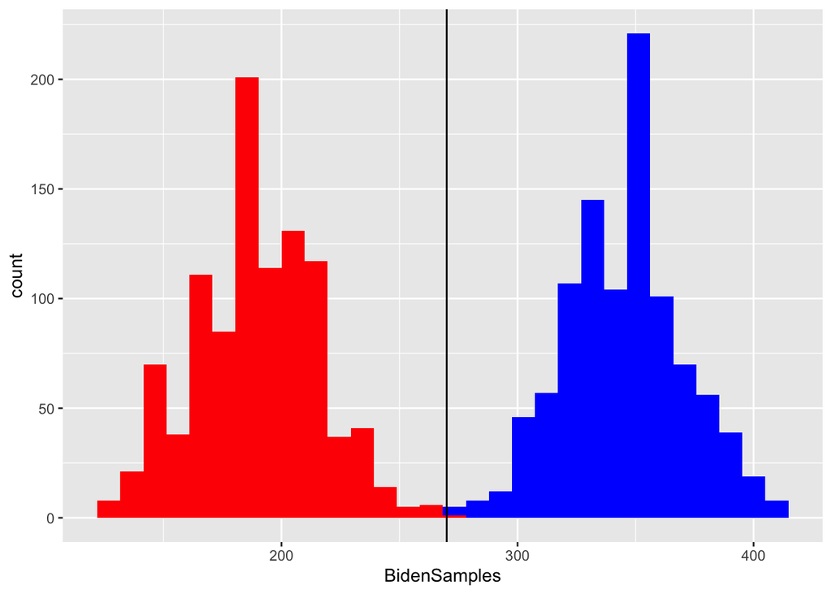

```r
BidenSamples <- apply(BidenExpectedEV,2,sum)
TrumpSamples <- apply(TrumpExpectedEV,2,sum)

ggplot(xlim=c(200,400)) +
  geom_histogram(mapping = aes(BidenSamples), fill = "blue") +
  geom_histogram(mapping = aes(TrumpSamples), fill = "red") +
  geom_vline(xintercept = 270)
```

To summarize the results for *both* Biden and Trump on the same plot we use a ggplot with a defined `xlim` to contain a reasonable scale for both candidates, but no data becasue we want to call the data separately for each `geom_histogram` that we will add. Then we will add histograms for Biden and Trump using the BidenSamples and TrumpSamples object we just created and fill the bars using red or blue to indicate Trump and Biden respectively. (Note that we need the `mapping=` command here because we are plotting a vector rather than a dataframe). Becasue it takes 270 Electoral College votes to win, we can add a vertical line using `geom_vline` and specifying the x intercept.

The plot is informative because it shows how the Electoral College votes were predicted to favor Biden given the polling that had been done (and the assumptions we have made). But it may not fully capture the question we are interested in, which is, “what is the probability that Biden will win?” Describing the distribtuion of EC votes is similar to this, but does not directly answer the question. Fortunately we can use what we have done to do so.

Recall that a candidate needs 270 Electoral College votes to win. We can use this fact to determine the probability that each candidate receives 270 Electoral College vote using the same approach we took earlier – the proportion of simulations in which the sum of the Electoral College votes exceed 270. To do so we simply need to determine the number of simulations for which each candidate gets more than 270 votes by evaluating whether the sum of the Electoral College votes in each simulation exceeds 270 or not and then determining the proportion of simulations for which this is true. We could also estimate the probability that Trump receives more than 270 Electoral College votes similarly, and even the chances of a tie in the Electoral College becasue both candidates received 270 votes. The beauty of the resampling approach we have taken is that we can effectively similar the probability of whatever outcome is of interest!

So let’s do this using the variables we have already created!

```r
sum(apply(BidenExpectedEV,2,sum) > 270)/1000
```

```
## [1] 0.997
```

```r
sum(apply(TrumpExpectedEV,2,sum) > 270)/1000
```

```
## [1] 0
```

```r
sum(apply(BidenExpectedEV,2,sum) == 270)/1000
```

```
## [1] 0
```

So the polling averages predict an overwhelming probability of success for Biden. Not quite what we observed during Election Week 2020…

# Next Steps?

How could you improve this? You could use the `rbinom` approach we took to resample the individual poll results before resampling the set of polls to see how this affects things. Note that this will not affect the state polling average (because of the LLN), but it will affect the variation of the state polling averages because instead of sampling from a fixed set of polls we would be sampling from a set of polls that vary. But note how quickly this escalates the computations required. Instead of taking the 143 PA polls as fixed, we would need to create a sample for each of the 143 polls and then when we sample the polls to create the state polling average we would be sampling from random samples. We can do this more efficietly using the `rbinom` command, but even that is trickly because the percentages are not two-candiate otucomes because polls allow respodnents to choose other options. (So perhaps rescale the variables into two-party percentages first?)

Relatedly, we assumed that the proportion of polls with Biden in the lead was the same as the probability of Biden winning. This is reasonable, but it is also consequential. If every statewide poll is 51-49, the fact that 100% of the polls have the same candidate in the lead assuredly overstates that probability. Resampling the polls to compute the fraction of polls where a candidate leads does not solve the issue because the polls in this example are all identical. Instead, we need to resample the individual polls to allow some of the 51-49 polls to produce wins for the other candidate (as it is extremely unlikely that these polls would all predict the same winner if we were to account for the uncertainty in each). So here is an example about thinking what you are assuming – and why it could be misleading! – is very important. Is it reasonable to use the proportion of polls where a candidate leads as a prediction for the probability that a candidate will win? Certainly yes, that is how we evaluate probabilities – the probability of a coin coming up heads is the same as the proportion of times it comes up heads after flipping it many, many times. But it can be consequential and you have to think about that.

A couple of possibilities. First, we calculated our uncertainty assuming random sampling. But perhaps this is the problem. And it could affect several calculations. Is it right to think of the sampled outcomes as being randomly selected from each state when generating the hypothetical results of the elections? Given national trends in politics, this is a strong assumption as it is saying that the value we sample in CA from the CA polling average is unrelated to the values we sample for other states. But it seems that in actual elections there are likely to be correlated trends – so if CA is above its polling average then so too are other states. So the issue may be in how we generated hypotehtical elections by drawing from the state predicted probabilities.

Or the problem may be in how we calcualted the predicted probabiliies. Independnet of the issue of translating proportions into percentages when the polls are close, we also assumed that every poll was a random sample of the electorate. But we know that pollsters know the results of other polls when they are conducting their own polling and we also know that pollsters must employ statistical adjustments to accoutn for the fact that so few people choose to respond to polls. So if pollsters are adjusting their results to make them look more like other polls – so called “herding” – then our random sampling of individual polls will be misleading because the individual polls may be misleading! If the polls being sampled are themselves not a random sample of the electorate - because they are being adjusted to resemeble one another – then our random sample of those polls is no longer assured to converge to the population mean. If the polls are adjusted to an incorrect result, our ability to use those polls to uncover the truth will be hampered.

Related to this issue is the possibility that the problem is not in the adjustments being done, but in terms of who responds (although these are related becasue issues in who responds leads pollsters to try to do corrections). If the polls are not random sample of the electorate, then the power of the LLN and CLT are irrelevant. If the people polls are talking to are different from the people who are voting – say that are too Democratic leaning – then we may have accounted for all of the uncertainty in a defensible way but we stuck because of errors in the underlying data. It is hard to fix misleadign data – especially if you are unsure of whether and how it may be misleading when doing the analysis!

[^1]: `abline` refers to the fact that the line is defined by a y-intercept (a) and a slope (b),